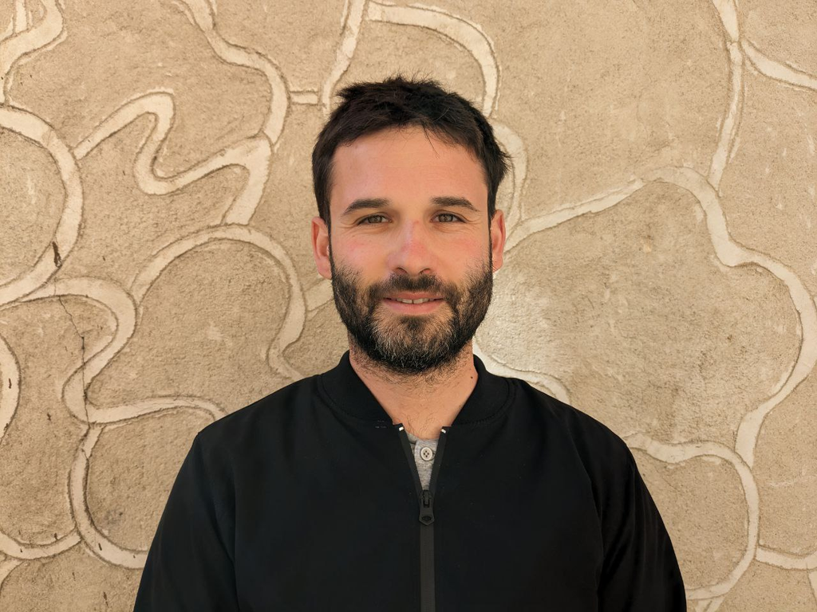

# Nicolas Robinson-Garcia

## Outreach

Opinion pieces and other non-academic outputs as well as news stories in which either me or my work have been mentioned.

## Opinion pieces and comments

[Luces y sombras del uso de la paridad de género en ciencia como indicador](https://nadaesgratis.es/admin/luces-y-sombras-del-uso-de-la-paridad-de-genero-en-ciencia-como-indicador) | **[Nada es Gratis](https://nadaesgratis.es/)**, Nov 14, 2024

[Excellent research and societal impact in the 2021 UK REF](https://www.sv.uio.no/tik/english/research/centre/osiris/osirisblog/excellent-research-and-societal-impact-in-the-2021.html) | **[OSIRIS Blog](https://www.sv.uio.no/tik/english/research/centre/osiris/osirisblog/)**, Oct 28, 2024

[La bibliometría forense y Los Hombres de Paco](https://thinkepi.scimagoepi.com/index.php/ThinkEPI/article/view/91637) | **ThinkEPI**, Mar, 2024

[WikiGenDex: Un nuevo algoritmo de identificación de género basado en fuentes abiertas](https://doi.org/10.3145/infonomy.24.010) | **Infonomy**, 2(1), e24010

[Acceso Abierto: utopías, realidades y cuentas pendientes](https://doi.org/10.3145/thinkepi.2023.e17a17) | **ThinkEPI**, Jun, 2023

[Contra el pensamiento mágico de la bibliometría](https://doi.org/10.3145/thinkepi.2022.e16a21) | **ThinkEPI**, 2022.

[Attention for science in step with policy? The case of school closures during COVID-19](https://www.leidenmadtrics.nl/articles/attention-for-science-in-step-with-policy-the-case-of-school-closures-during-covid-19) | **Leiden Madtrics**, 2021

[It’s time to recognise the diversity of research careers](https://www.researchprofessionalnews.com/rr-funding-insight-2021-2-it-s-time-to-recognise-the-diversity-of-research-careers/) | **ResearchProfessional News**, 2021

[Is there a standard research career? The unintended consequences of task specialisation in science](https://blogs.lse.ac.uk/impactofsocialsciences/2021/02/01/is-there-a-standard-research-career-the-unintended-consequences-of-task-specialisation-in-science/) | **LSE Impact Blog**, February 1, 2021

[The unintended consequences of task specialization in research careers](https://www.leidenmadtrics.nl/articles/the-unintended-consequences-of-task-specialization-in-research-careers) | **Leiden Madtrics**, Nov, 23, 2020

[Where do scholars move? Measuring the mobility of researchers across academic institutions](https://www.leidenmadtrics.nl/articles/where-do-scholars-move-measuring-the-mobility-of-researchers-across-academic-institutions) | **Leiden Madtrics**, Sept 3, 2020.

[An interview with Juan Gorraiz](https://thebibliomagician.wordpress.com/2020/03/25/interview-with-juan-gorraiz/) | **The Bibliomagician**, March 25, 2020

[Results from the 2019 Responsible Metrics State of the Art Survey](https://thebibliomagician.wordpress.com/2019/11/12/results-from-the-2019-responsible-metrics-state-of-the-art-survey/) | **The Bibliomagician**, Nov 12, 2019

[Indicators of open access publishing in the CWTS Leiden Ranking 2019](https://www.cwts.nl/blog?article=n-r2w2a4) | **CWTS Blog**, May 15, 2019.

[La financiación de las universidades británicas a examen: ¿Excelencia científica o relevancia social?](https://nadaesgratis.es/admin/la-financiacion-de-las-universidades-britanicas-a-examen-excelencia-cientifica-o-relevancia-social) | **Nada es Gratis**, Mar 9, 2018.

[Los resultados del REF2014 de Reino Unido marcan el camino a seguir en la evaluación científica](https://www.ub.edu/blokdebid/es/content/los-resultados-del-ref2014-del-reino-unido-marcan-el-camino-seguir-en-la-evaluacion) | **Blok de BiD**, Dec 12, 2017.

[The global scientific brain: Policy implications of barriers to scientific mobility](https://www.cwts.nl/blog?article=n-r2r284) | **CWTS Blog**, Oct 5, 2017.

[The 2014 REF results show only a very weak relationship between excellence in research and achieving societal impact](https://blogs.lse.ac.uk/impactofsocialsciences/2017/07/19/what-do-the-2014-ref-results-tell-us-about-the-relationship-between-excellent-research-and-societal-impact/) | **LSE Impact Blog**, July, 19, 2017.

[How to make altmetrics useful in societal impact assessments: shifting from citation to interaction approaches](https://blogs.lse.ac.uk/impactofsocialsciences/2017/03/23/how-to-make-altmetrics-useful-in-societal-impact-assessments-shifting-from-citation-to-interaction-approaches/?share=pocket) | **LSE Impact Blog**, March, 23, 2017.

[Los nuevos índices de citas de Thomson Reuters ofrecen oportunidades para mejorar los rankings de universidades](https://zenodo.org/record/1043364) | **Anuario ThinkEPI**, 2014, 9, 207-210.

## Featured elsewhere

[ORCID Celebrates Open Access Week with Release of Public Data File](https://info.orcid.org/orcid-celebrates-open-access-week-with-release-of-public-data-file/). **ORCID**, October 24, 2023

[Scientists at odds on Utrecht University reforms to hiring and promotion criteria](https://www.nature.com/nature-index/news-blog/scientists-argue-over-use-of-impact-factors-for-evaluating-research). **Nature Index**, August 9, 2021.

[You’ve tweeted about your hot new paper! Don’t expect many clicks](https://www.science.org/content/article/you-ve-tweeted-about-your-hot-new-paper-don-t-expect-many-clicks). **Science**, February 12, 2021.

[Scientists are drowning in COVID-19 papers. Can new tools keep them afloat?](https://www.science.org/content/article/scientists-are-drowning-covid-19-papers-can-new-tools-keep-them-afloat) **Science** May 14, 2020.

[Science has more impact when researchers travel, collaborate](https://www.upi.com/Science_News/2017/11/09/Science-has-more-impact-when-researchers-travel-collaborate/8481510092041/). **United Press International**. Nov 9, 2017

[P09 - #Evaluando en la I Reunión de Servicios de Evaluación Científica en los Vicerrectorados de Investigación](https://www.ivoox.com/p09-evaluando-i-reunion-de-audios-mp3_rf_32995477_1.html) **Radiolab UGR**. Oct 27, 2017

[Las fronteras, una amenaza para la producción e impacto científico internacional, según un estudio](https://www.europapress.es/comunitat-valenciana/noticia-fronteras-amenaza-produccion-impacto-cientifico-internacional-estudio-20171006121658.html). **Europa Press**. Oct 6, 2017

[La fuite des cerveaux est bonne pour la recherche.](https://www.lepoint.fr/sciences-nature/la-fuite-des-cerveaux-est-bonne-pour-la-recherche-06-10-2017-2162688_1924.php#11) **Le Point Sciences**. Oct 6, 2017.

[Audio fil du vendredi 6 octubre 2017. Étude: Mobilité des chercheurs menacée par Trump et le Brexit.](https://ici.radio-canada.ca/ohdio/premiere/emissions/l-heure-de-pointe-toronto/episodes/391391/audio-fil-du-vendredi-6-octobre-2017). **L’Heure de point**. Oct 6, 2017.

[Researchers who change country produce more influential work](https://www.economist.com/science-and-technology/2017/10/07/researchers-who-change-country-produce-more-influential-work). **The Economist**, Oct 4, 2017.

[Migrating researchers are cited the most](https://doi.org/10.1126/science.aaq1218). **Science**, Oct 4, 2017.

[Editorial: Science without walls is good for all](https://doi.org/10.1038/550007b). **Nature**, 2017, 550, 7-8.

[Fresh data supports freedom of movement for scientists](https://www.timeshighereducation.com/news/fresh-data-support-freedom-movement-scientists). **Times Higher Education Magazine**, Oct 4, 2017.

[Tweets on academic papers ‘mechanical and devoid of original thought’](https://www.timeshighereducation.com/news/tweets-academic-papers-mechanical-and-devoid-original-thought). **Times Higher Education Magazine**, Sept 2, 2017.

[The “unbearable emptiness” of Science in Twitter?](http://blogs.discovermagazine.com/neuroskeptic/?p=9080&alm_mvr=0) **Discover Magazine**, Aug 27, 2017.

[Publishers withdraw more than 120 gibberish papers](https://doi.org/10.1038/nature.2014.14763). **Nature**, Feb 24, 2014.

[Google Scholar wins raves - But can it be trusted?](https://doi.org/10.1126/science.343.6166.14) **Science**, 2014, 343(6166), 14.

[Radioscopio en revisión](https://www.ivoox.com/radioscopio-n-072-radioscopio-revision-audios-mp3_rf_2676279_1.html) **El Radioscopio**. Canal Sur Radio, Dec 28, 2013

[Las grandes revistas científicas y los métodos de medición, cada vez más cuestionados](https://www.ivoox.com/a-hombros-gigantes-las-grandes-revistas-cientificas-y-audios-mp3_rf_2647117_1.html) **A hombros de gigantes**. Radio Nacional de España, Dec 16, 2013.

[Así lograron engañar a Google varios científicos españoles](https://www.abc.es/tecnologia/redes/20131214/abci-google-hackear-cientificos-201312141935.html). **ABC**, Dec 14, 2013.